# Final Report

Joe Omatoi

2022-11-08

```r
# load pacakges ----
library(tidyverse)
library(skimr)
library(sf)
library(shiny)

# load data ----

# provided data
basic_dat <- read_csv("data/basic_dat.csv") %>%
  janitor::clean_names() %>%
  rename(properties_owned = properties_held_by_taxpayer_match_code) %>%
  rename(address = property_address) %>%
  select(address, community_area, taxpayer_match_code, lat, long, properties_owned)

# illinois community area data from web
map_dat <- read_sf("https://raw.githubusercontent.com/thisisdaryn/data/master/geo/chicago/Comm_Areas.geojson") %>%
  rename(community_area = community) %>%
  mutate(community_area = tools::toTitleCase(tolower(community_area)))

# combined data
dat <- basic_dat %>%
  left_join(map_dat, by = "community_area")
```

## Project overview

This project was done for Lift the Ban Coalition, an non-profit organization with the goal of lifting the ban on rent control in Illinois. Lift the Ban Coalition wants to enforce rent control to make rent more affordable in Illinois. However, the counterargument is that rent control should be banned as it harms the “mom and pop”, “small” landlords. The task was to evaluate whether there are many “mom and pop” landlords to be harmed from rent control and come up with possible ways to make rent more affordable while limiting the harm on “small” landlords. This report presents data in a digestable manner and helps the organization craft appropriate legislation.

## Data

Two datasets were combined for this project.

The second dataset was the [IL Community Area data](https://raw.githubusercontent.com/thisisdaryn/data/master/geo/chicago/Comm_Areas.geojson%22), which contained supplementary geographic data needed to visualize property characteristics across Illinois for exploratory purposes.

Both datasets were joined by the common community area column.

## Approach

The task follows the next 2 approaches.

1. Uncover proportions/count of “big” vs “small” landlords

   The idea is to define who counts as a “small” landlord and evaluate the claim that many “small” landlords will get affected by rent control by looking at the proportion and number of “small” landlords. The number of properties owned (with varying thresholds) is used to define “small” landlords who are identified by the taxpayer match code.
2. Identify areas where majority of properties are owned by “big” landlords

## Exploratory Analysis

All the variables are complete, meaning we have no missingness issues.

```r
basic_dat %>%
  skim_without_charts()
```

Data summary

| Name | Piped data |
| --- | --- |
| Number of rows | 129907 |
| Number of columns | 6 |
| _______________________ |  |
| Column type frequency: |  |
| character | 3 |
| numeric | 3 |
| ________________________ |  |
| Group variables | None |

**Variable type: character**

| skim_variable | n_missing | complete_rate | min | max | empty | n_unique | whitespace |
| --- | --- | --- | --- | --- | --- | --- | --- |
| address | 0 | 1 | 10 | 39 | 0 | 129619 | 0 |
| community_area | 0 | 1 | 4 | 22 | 0 | 77 | 0 |
| taxpayer_match_code | 0 | 1 | 7 | 8 | 0 | 96062 | 0 |

**Variable type: numeric**

| skim_variable | n_missing | complete_rate | mean | sd | p0 | p25 | p50 | p75 | p100 |
| --- | --- | --- | --- | --- | --- | --- | --- | --- | --- |
| lat | 0 | 1 | 41.87 | 0.08 | 41.64 | 41.80 | 41.89 | 41.94 | 42.02 |
| long | 0 | 1 | -87.69 | 0.05 | -87.85 | -87.72 | -87.69 | -87.66 | -87.52 |
| properties_owned | 0 | 1 | 15.96 | 91.60 | 1.00 | 1.00 | 1.00 | 2.00 | 931.00 |

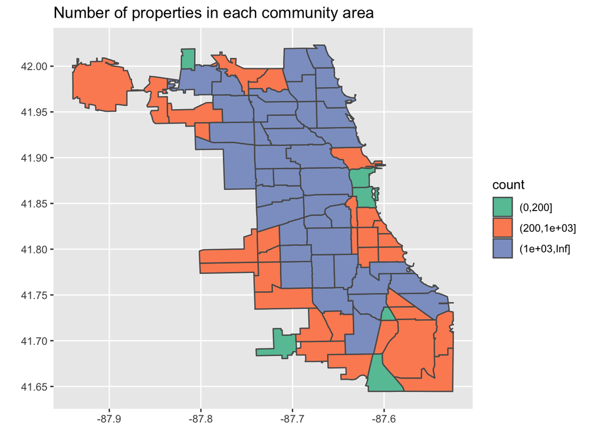

```r
dat %>%
  group_by(community_area) %>%
  mutate(count = n()) %>%
  select(count, community_area, geometry) %>%
  distinct(community_area, .keep_all = TRUE) %>%
  mutate(count = cut(count, c(0, 200, 1000, Inf))) %>%
  ggplot(aes(fill = count, geometry = geometry)) +
  geom_sf() +
  scale_fill_brewer(palette = "Set2") +
  labs(
    title = "Number of properties in each community area"
  )
```

## Analysis

[figure not shown]

```r
shinyApp(

  ui <- fluidPage(

    titlePanel(""),

    sidebarLayout(
        sidebarPanel(
            sliderInput("threshold",
                        "Adjust number of properties ",
                        min = 3,
                        max = 300,
                        value = 6)
            ),
            mainPanel(plotOutput("distPlot"))
    )
  ),

  server <- function(input, output) {

  output$distPlot <- renderPlot({

    text <- basic_dat %>%
      distinct(taxpayer_match_code, .keep_all = T) %>%
      mutate(
        properties_owned = if_else(properties_owned < input$threshold, paste('<', input$threshold), paste('>', input$threshold))
      ) %>%
      group_by(properties_owned) %>%
      count()

    text2 <- text %>%
      mutate(
        x = 'x',
        n = if_else(properties_owned == paste('<', input$threshold), sum(text$n), n)
      )

    text3 <- text %>%
      mutate(
        n = paste(round(n/sum(text$n)*100, 0), '%')
      )

    df_2 %>%
      filter(!is.na(properties_owned)) %>%
      distinct(taxpayer_match_code, .keep_all = T) %>%
      mutate(
        x = "x",
        properties_owned = if_else(properties_owned <input$threshold, paste('<', input$threshold), paste('>', input$threshold))
      ) %>%
      ggplot() +
      aes(x = x, fill = properties_owned) +
      geom_bar(color = "white", alpha = 0.75) +
      annotate(
        geom = "text",
        x = text2$x,
        y = text2$n - text$n/2,
        label = if(input$raw == T) (text$n) else (text3$n),
        size = 10
      ) +
      coord_polar("y") +
      theme(
        # panel.background = element_blank(),
        axis.text = element_blank(),
        axis.ticks = element_blank(),
        panel.grid.major.y = element_blank(),
      ) +
      # theme_void() +
      labs(
        fill = "Properties owned",
        x = NULL,
        y = NULL,
        title = paste("Figure 2. Percentage/number of landlords that own more/less than", input$threshold, "properties", sep = " ")
      )
  })
  }
)
```

```r
# shinyApp(
#
#
# )
```